# Reading Comprehension

```r
#Play the above chunk and this one in your Console to access the data
View(Baumann)
?Baumann
```

### Background

“This study investigated the effectiveness of explicit instruction in ‘think aloud’ as a means to promote elementary students’ comprehension monitoring abilities” [(Baumann & Jones, 1992)](http://jlr.sagepub.com/content/24/2/143.full.pdf).

Details of the Study (click to view)

The Data (click to view)

From the details of the study we see that reading comprehension can be measured in many different ways, and in the case of this study we have three. Also, each experirmental teaching group may have a greater focus on a specific measuring type than another.

For this reason the analysis will look at each type of test separately. This will provide each teaching group a fair chance to show improvement if it exists. Consequently alpha of 0.05 will also be split between the 3 analyses as well.

### Type 1 Test

#### Hypothesis of Type 1 Tests

This analysis will look at the difference of scores between each group. A Kruskal-Wallis test will be done on `Diff1` which was created by `post.test.1 - pretest.1`.

Our null and alternative are written as thus,

$$H_0: \text{= All samples represent a sample of data from the same distribution}$$
$$H_a: \text{= At least one distribution is stochastically different than the others}$$

Level of significance will be defined as $\alpha$=0.017

#### Analysis of Type 1 Tests

The results of the Kruskal-Wallis tests are as follows,

```r
pander(kruskal.test(Diff1 ~ group, data=Baumann))
```

Kruskal-Wallis rank sum test: `Diff1` by `group`

| Test statistic | df | P value |
| --- | --- | --- |
| 17.93 | 2 | 0.0001276 * * * |

The p-value of our test is smaller than the level of significance therefore we **reject the null hypothesis**. Indeed, there is a difference in distribution for at least one of the experimental groups. The significance of the test also leads us to believe that this represents the parent population.

The boxplot and the statistical summary table shown below support these findings.

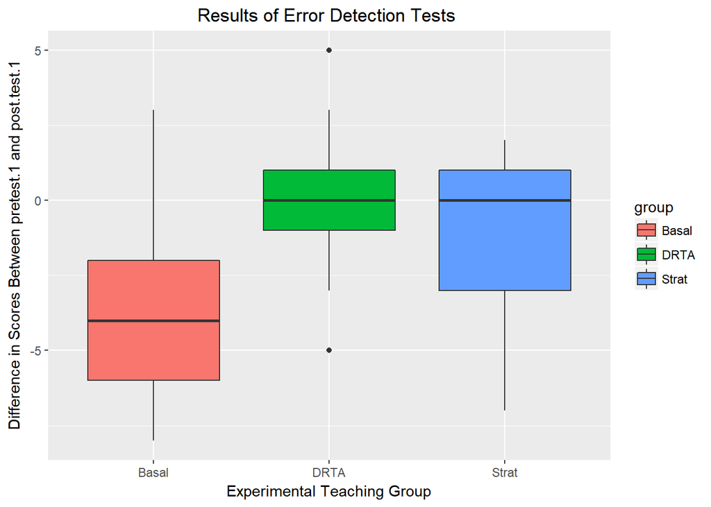

```r
ggplot(data=Baumann, aes(x = group, fill = group)) +
  geom_boxplot(aes(y = Diff1)) +
  ggtitle("Results of Error Detection Tests ") +
  ylab("Difference in Scores Between pretest.1 and post.test.1") +
  xlab("Experimental Teaching Group") +
  theme(plot.title = element_text(hjust = .5))
```

```r
pander(favstats(Diff1 ~ group, data = Baumann))
```

| group | min | Q1 | median | Q3 | max | mean | sd | n | missing |
| --- | --- | --- | --- | --- | --- | --- | --- | --- | --- |
| Basal | -8 | -6 | -4 | -2 | 3 | -3.818 | 2.872 | 22 | 0 |
| DRTA | -5 | -1 | 0 | 1 | 5 | 0.04545 | 2.171 | 22 | 0 |
| Strat | -7 | -3 | 0 | 1 | 2 | -1.364 | 2.647 | 22 | 0 |

#### Interpretation for Type 1 Tests

The test and boxplot suggests that the experimental teaching group Basal preformed worse than their pre-test. It appears that the teaching style of this group did not prepare the students to detect errors. In fact the experiment seems to have hampered their ability.

If it is the primary goal to have student detect errors and inconsistencies, which is potentially very useful skill in many professions, then this teaching style proves to be ineffective. The mean and medians of the other two groups, DRTA and Strat also do not appear to have any positive influence on the students, although this hasn’t been proven statistically. This analysis suggests that other methods of teaching should be researched and implemented.

### Type 2 Test

#### Hypothesis of Type 2 Tests

This analysis will look at the difference of scores between each group. A Kruskal-Wallis test will also be done on `Diff2` which was created by `post.test.2 - pretest.2`.

Our null and alternative are written as thus,

$$H_0: \text{= All samples represent a sample of data from the same distribution}$$
$$H_a: \text{= At least one distribution is stochastically different than the others}$$

Level of significance will be defined as $\alpha$=0.017

#### Analysis of Type 2 Tests

```r
pander(kruskal.test(Diff2 ~ group, data=Baumann))
```

Kruskal-Wallis rank sum test: `Diff2` by `group`

| Test statistic | df | P value |
| --- | --- | --- |
| 15.45 | 2 | 0.0004406 * * * |

Similarly to the type 1 test, the p-value leads us to **reject the null hypothesis**. One or more samples do in fact have a different distribution.

We can see the distribution of the groups from the boxplot shown below.

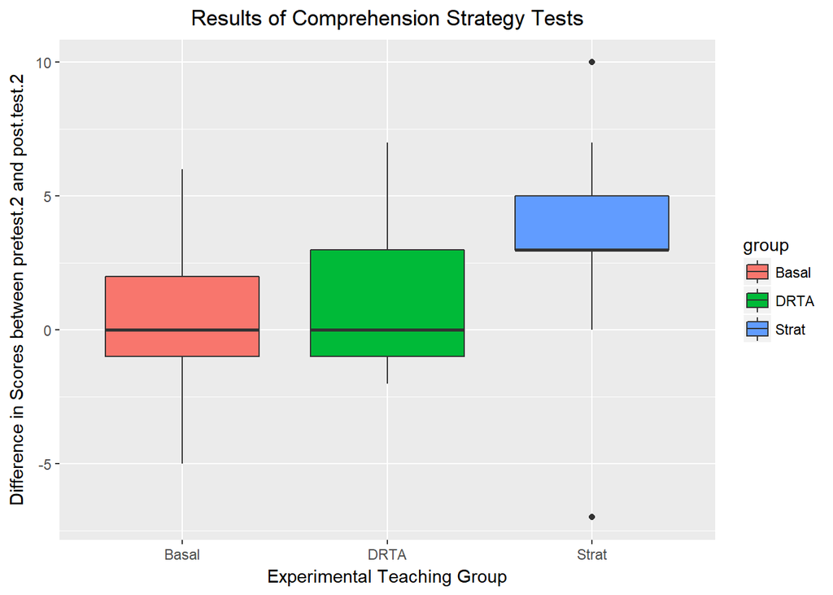

```r
ggplot(data=Baumann, aes(x = group, fill = group)) +
  geom_boxplot(aes(y = Diff2)) +
  ggtitle("Results of Comprehension Strategy Tests") +
  ylab("Difference in Scores between pretest.2 and post.test.2") +
  xlab("Experimental Teaching Group") +
  theme(plot.title = element_text(hjust = .5))
```

```r
pander(favstats(Diff2 ~ group, data = Baumann))
```

| group | min | Q1 | median | Q3 | max | mean | sd | n | missing |
| --- | --- | --- | --- | --- | --- | --- | --- | --- | --- |
| Basal | -5 | -1 | 0 | 2 | 6 | 0.2727 | 2.585 | 22 | 0 |
| DRTA | -2 | -1 | 0 | 3 | 7 | 1.136 | 2.587 | 22 | 0 |
| Strat | -7 | 3 | 3 | 5 | 10 | 3.409 | 3.217 | 22 | 0 |

#### Interpretation of Type 2 Tests

Considering that the pre and post test 2 dealt with comprehension strategies, we see that the Strat teaching style better equipped students with the tools they need to read and understand material presented to them. The analysis suggests that the teaching involved with the Strat group is a potential candidate for an effective method of instruction.

### Type 3 Test

#### Hypothesis of Type 3 Tests

Due to the fact that a pretest of the type 3 test was not delivered to the students we are unable to treat this as we did the two types of tests. Therefore this analysis will not look at which group improved the most, but rather which group preformed the best with the given test. The data `post.test.3` will be used in the Kruskal-Wallis test.

Our null and alternative hypothesis will be similarly written as thus,

$$H_0: \text{= All samples represent a sample of data from the same distribution}$$
$$H_a: \text{= At least one distribution is stochastically different than the others}$$

#### Analysis of Type 3 Tests

```r
pander(kruskal.test(post.test.3 ~ group, data=Baumann))
```

Kruskal-Wallis rank sum test: `post.test.3` by `group`

| Test statistic | df | P value |
| --- | --- | --- |
| 9.632 | 2 | 0.0081 * * |

Just like the other two analyses we have a low p-value, therefore, the **null hypothesis is rejected** and we conclude the alternative.

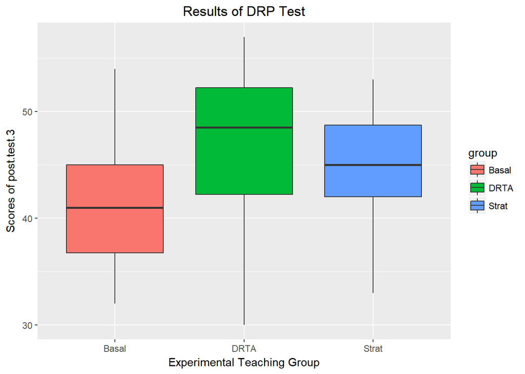

```r
ggplot(data=Baumann, aes(x = group, fill = group)) +
  geom_boxplot(aes(y = post.test.3)) +
  ggtitle("Results of DRP Test") +
  ylab("Scores of post.test.3") +
  xlab("Experimental Teaching Group") +
  theme(plot.title = element_text(hjust = .5))
```

```r
pander(favstats(post.test.3 ~ group, data = Baumann))
```

| group | min | Q1 | median | Q3 | max | mean | sd | n | missing |
| --- | --- | --- | --- | --- | --- | --- | --- | --- | --- |
| Basal | 32 | 36.75 | 41 | 45 | 54 | 41.05 | 5.636 | 22 | 0 |
| DRTA | 30 | 42.25 | 48.5 | 52.25 | 57 | 46.73 | 7.388 | 22 | 0 |
| Strat | 33 | 42 | 45 | 48.75 | 53 | 44.27 | 5.767 | 22 | 0 |

## Final Interpretation

The results of this analysis shows that certain groups performed better, and in one case worse, at specific tests of comprehension. The only clear result we got was that Strat performed better when it came to testing comprehension strategies, and the DRTA grouped preformed better when it came testing the student’s ability to process and understand reading material.

The suggestion can be made that researchers take a deeper look at the methods of each group. Take what worked the best from Strat and from DRTA and use it to create another method that could potentially work well in more than one key area of measuring comprehension.

Source

Moore, D. S. and McCabe, G. P. (1993) Introduction to the Practice of Statistics, Second Edition. Freeman, p. 794–795.

References

Fox, J. (2008) Applied Regression Analysis and Generalized Linear Models, Second Edition. Sage.

Fox, J. and Weisberg, S. (2011) An R Companion to Applied Regression, Second Edition, Sage.